# Doktorandenmeeting 31.03.21

Marianne Tokic

3/31/2021

## klassische Krankheitsaktivität bei RR-MS und Schwangerschaft: PRIMS Studie

- 227 größtenteils untherapierte RR-MS Patienten
- ARR vor, in und nach der Schwangerschaft erhoben

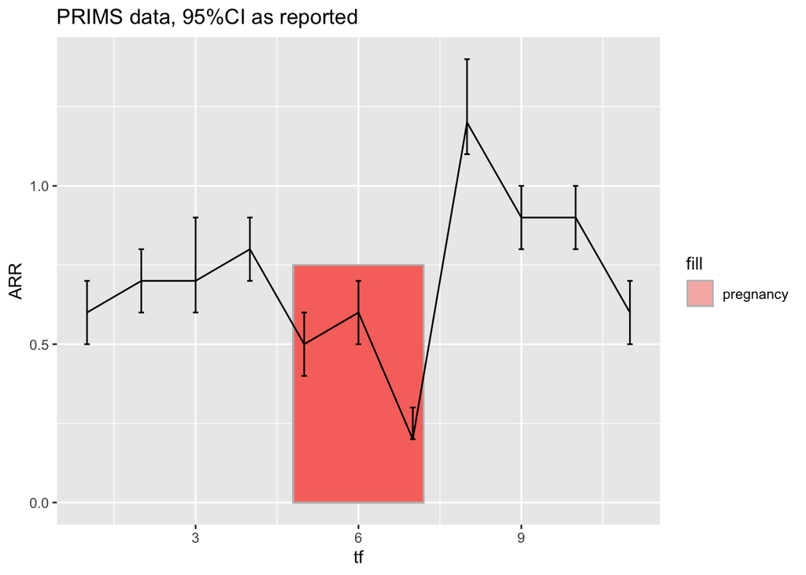

## Simulation von untherapierten Schwangerschaftsverläufen

- es ist unklar wie die zeitanhängigen Effekte der Schwangerschaft und der Therapie interagieren
- auch ist unklar welches die beste Auswertungstrategie zur Klärung dieser Frage ist
- Simulation: reda::simEvent oder simrec – simEvent hat ein Update bekommen, welches diese Funktion interresant macht

## simEvent

- simuliert wiederkehrende Ereignisse als Poisson-Prozesse
- verschiedene Einstellmöglichkeiten – frei modellierbare baseline hazard Rate – frailty – “Cooldown” Zeit zwischen Events (interarrival time)

## Bisher umgesetzt (neu)

- Baseline hazard (vereinfacht vor der Schwangerschaft)
- Simulation von 10 x 100 IDs

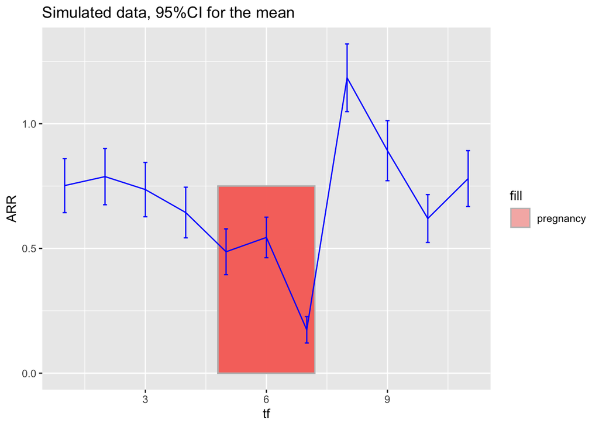

## Interarrival time (IAT) > 30

- Als nächstes muss die IAT so gesetzt werden, dass mindestens 30 Tage ziwschen den Events liegen
- simEvent nimmt als IAT Funktion frei bestimmte Funktionen " A function object for randomly generating (positive) interarrival time between two successive arrivals/events. The default value is “rexp” (i.e., function stats::rexp) for generating interarrival times following exponential distribution, which leads to a Poisson process. If the assumption of exponential interarrival times cannot be justified, we may consider a renewal process, (a generalization of Poisson process), in which interarrival times between events independently follows an identical distribution. A customized function can be specified in this case. It must have at least one argument named rate for the expected number of arrivals/events in unit time and returns one positive numerical value. If the function contains an argument named n, it is assumed that the function returns n interarrival times in one function call to possibly speed up the random number generation procedure. Other arguments can be specified through a named list inside arguments."

## Frage:

Wie spezifiziere ich die IAT? - mindestens 30 Tag - oberes Ende: unbekannt - ehrlich gesagt verstehe ich die Anleitung nicht komplett an der Stelle